# Data

## Import Libraries

```python
import pandas as pd
import numpy as np
import seaborn as sns
import matplotlib.pyplot as plt
```

## Data Wrangling

#### Import Files

```python
transaction_data = pd.read_excel(r"C:\Users\jolis\Documents\Cert\Quantium\QVI_transaction_data.xlsx")
purchase_behaviour = pd.read_csv(r"C:\Users\jolis\Documents\Cert\Quantium\QVI_purchase_behaviour.csv")
```

```python
transaction_data.head()
```

|  | DATE | STORE_NBR | LYLTY_CARD_NBR | TXN_ID | PROD_NBR | PROD_NAME | PROD_QTY | TOT_SALES |
| --- | --- | --- | --- | --- | --- | --- | --- | --- |
| 0 | 43390 | 1 | 1000 | 1 | 5 | Natural Chip Compny SeaSalt175g | 2 | 6.0 |
| 1 | 43599 | 1 | 1307 | 348 | 66 | CCs Nacho Cheese 175g | 3 | 6.3 |
| 2 | 43605 | 1 | 1343 | 383 | 61 | Smiths Crinkle Cut Chips Chicken 170g | 2 | 2.9 |
| 3 | 43329 | 2 | 2373 | 974 | 69 | Smiths Chip Thinly S/Cream&Onion 175g | 5 | 15.0 |
| 4 | 43330 | 2 | 2426 | 1038 | 108 | Kettle Tortilla ChpsHny&Jlpno Chili 150g | 3 | 13.8 |

```python
purchase_behaviour.head()
```

|  | LYLTY_CARD_NBR | LIFESTAGE | PREMIUM_CUSTOMER |
| --- | --- | --- | --- |
| 0 | 1000 | YOUNG SINGLES/COUPLES | Premium |
| 1 | 1002 | YOUNG SINGLES/COUPLES | Mainstream |
| 2 | 1003 | YOUNG FAMILIES | Budget |
| 3 | 1004 | OLDER SINGLES/COUPLES | Mainstream |
| 4 | 1005 | MIDAGE SINGLES/COUPLES | Mainstream |

#### Merge Files

```python
customer_data = pd.merge(transaction_data,purchase_behaviour,how = 'left', on = 'LYLTY_CARD_NBR')
customer_data.head()
```

|  | DATE | STORE_NBR | LYLTY_CARD_NBR | TXN_ID | PROD_NBR | PROD_NAME | PROD_QTY | TOT_SALES | LIFESTAGE | PREMIUM_CUSTOMER |
| --- | --- | --- | --- | --- | --- | --- | --- | --- | --- | --- |
| 0 | 43390 | 1 | 1000 | 1 | 5 | Natural Chip Compny SeaSalt175g | 2 | 6.0 | YOUNG SINGLES/COUPLES | Premium |
| 1 | 43599 | 1 | 1307 | 348 | 66 | CCs Nacho Cheese 175g | 3 | 6.3 | MIDAGE SINGLES/COUPLES | Budget |
| 2 | 43605 | 1 | 1343 | 383 | 61 | Smiths Crinkle Cut Chips Chicken 170g | 2 | 2.9 | MIDAGE SINGLES/COUPLES | Budget |
| 3 | 43329 | 2 | 2373 | 974 | 69 | Smiths Chip Thinly S/Cream&Onion 175g | 5 | 15.0 | MIDAGE SINGLES/COUPLES | Budget |
| 4 | 43330 | 2 | 2426 | 1038 | 108 | Kettle Tortilla ChpsHny&Jlpno Chili 150g | 3 | 13.8 | MIDAGE SINGLES/COUPLES | Budget |

#### Finding the number of missing values

```python
customer_data.isnull().sum().sum()
```

```
0
```

#### Datatype Check

```python
customer_data.dtypes
```

```
DATE                  int64
STORE_NBR             int64
LYLTY_CARD_NBR        int64
TXN_ID                int64
PROD_NBR              int64
PROD_NAME            object
PROD_QTY              int64
TOT_SALES           float64
LIFESTAGE            object
PREMIUM_CUSTOMER     object
dtype: object
```

Converting the 'Date' Column's data type to **datetime64**

```python
customer_data['DATE'] = pd.to_datetime(customer_data['DATE'], origin='1899-12-30', unit='D')
customer_data.dtypes
```

```
DATE                datetime64[ns]
STORE_NBR                    int64
LYLTY_CARD_NBR               int64
TXN_ID                       int64
PROD_NBR                     int64
PROD_NAME                   object
PROD_QTY                     int64
TOT_SALES                  float64
LIFESTAGE                   object
PREMIUM_CUSTOMER            object
dtype: object
```

#### Data Cleaning of the 'PROD_NAME' column

```python
customer_data.head()
```

|  | DATE | STORE_NBR | LYLTY_CARD_NBR | TXN_ID | PROD_NBR | PROD_NAME | PROD_QTY | TOT_SALES | LIFESTAGE | PREMIUM_CUSTOMER |
| --- | --- | --- | --- | --- | --- | --- | --- | --- | --- | --- |
| 0 | 2018-10-17 | 1 | 1000 | 1 | 5 | Natural Chip Compny SeaSalt175g | 2 | 6.0 | YOUNG SINGLES/COUPLES | Premium |
| 1 | 2019-05-14 | 1 | 1307 | 348 | 66 | CCs Nacho Cheese 175g | 3 | 6.3 | MIDAGE SINGLES/COUPLES | Budget |
| 2 | 2019-05-20 | 1 | 1343 | 383 | 61 | Smiths Crinkle Cut Chips Chicken 170g | 2 | 2.9 | MIDAGE SINGLES/COUPLES | Budget |
| 3 | 2018-08-17 | 2 | 2373 | 974 | 69 | Smiths Chip Thinly S/Cream&Onion 175g | 5 | 15.0 | MIDAGE SINGLES/COUPLES | Budget |
| 4 | 2018-08-18 | 2 | 2426 | 1038 | 108 | Kettle Tortilla ChpsHny&Jlpno Chili 150g | 3 | 13.8 | MIDAGE SINGLES/COUPLES | Budget |

```python
customer_data['PROD_NAME'].str.strip()
customer_data['PROD_NAME'] = customer_data['PROD_NAME'].str.replace(r'\s{2,}', ' ', regex=True)  # Replace multiple spaces with one
customer_data['PROD_NAME'] = customer_data['PROD_NAME'].str.replace(r'(?<!\b[A-Z])([a-z])([A-Z])', r'\1 \2', regex=True)  # Add space before uppercase letters, ignoring consecutive uppercase letters
# filtered_df['PROD_NAME'] = filtered_df['PROD_NAME'].str.replace(r'(?<=[a-z])(?=[A-Z])', ' ', regex=True) # Add space before uppercase if preceded by lowercase
customer_data['PROD_NAME'] = customer_data['PROD_NAME'].str.replace(r'&', ' & ', regex=False)  # Add space before and after '&'
customer_data.head()
```

|  | DATE | STORE_NBR | LYLTY_CARD_NBR | TXN_ID | PROD_NBR | PROD_NAME | PROD_QTY | TOT_SALES | LIFESTAGE | PREMIUM_CUSTOMER |
| --- | --- | --- | --- | --- | --- | --- | --- | --- | --- | --- |
| 0 | 2018-10-17 | 1 | 1000 | 1 | 5 | Natural Chip Compny Sea Salt175g | 2 | 6.0 | YOUNG SINGLES/COUPLES | Premium |
| 1 | 2019-05-14 | 1 | 1307 | 348 | 66 | CCs Nacho Cheese 175g | 3 | 6.3 | MIDAGE SINGLES/COUPLES | Budget |
| 2 | 2019-05-20 | 1 | 1343 | 383 | 61 | Smiths Crinkle Cut Chips Chicken 170g | 2 | 2.9 | MIDAGE SINGLES/COUPLES | Budget |
| 3 | 2018-08-17 | 2 | 2373 | 974 | 69 | Smiths Chip Thinly S/Cream & Onion 175g | 5 | 15.0 | MIDAGE SINGLES/COUPLES | Budget |
| 4 | 2018-08-18 | 2 | 2426 | 1038 | 108 | Kettle Tortilla Chps Hny & Jlpno Chili 150g | 3 | 13.8 | MIDAGE SINGLES/COUPLES | Budget |

Some Products listed are not chips? As we are only interested in chips, the identified entries that are chips (even if the word "chips" isn't explicitly mentioned in the PROD_NAME column), using a combination of keyword matching, domain knowledge, and manual review.

```python
# Define chip-related keywords
chip_keywords = ["Chips", "Chip", "Potato", "Corn", "Tortilla", "Infzns Crn","Pringles","NCC", "Thins","Smiths","Crisps","Doritos", "CCs","Red Rock Deli","RRD", "Tostitos", "Twisties", "Infuzions", "Popd", "Cobs","Crinkle", "Kettle", "Waves","Puffs"]

# Identify rows that match the keywords
customer_data['Is_Chip'] = customer_data['PROD_NAME'].str.contains('|'.join(chip_keywords), case=False, na=False)

# Separate matched and unmatched rows for further review
chips_df = customer_data[customer_data['Is_Chip'] == True].copy()
# Rows identified as chips and using the copy to is an independent DataFrame, and any modifications to it will not affect the original customer_data.
non_chips_df = customer_data[customer_data['Is_Chip'] == False]  # Rows to manually review

# Display results
print("Entries identified as chips:")
print(chips_df['PROD_NAME'])

print("\nEntries to manually review:")
print(non_chips_df['PROD_NAME'])
```

```
Entries identified as chips:
0                    Natural Chip Compny Sea Salt175g
1                               CCs Nacho Cheese 175g
2               Smiths Crinkle Cut Chips Chicken 170g
3             Smiths Chip Thinly S/Cream & Onion 175g
4         Kettle Tortilla Chps Hny & Jlpno Chili 150g
                             ...
264831        Kettle Sweet Chilli And Sour Cream 175g
264832                   Tostitos Splash Of Lime 175g
264833                          Doritos Mexicana 170g
264834        Doritos Corn Chip Mexican Jalapeno 150g
264835                   Tostitos Splash Of Lime 175g
Name: PROD_NAME, Length: 241961, dtype: object

Entries to manually review:
5           Old El Paso Salsa Dip Tomato Mild 300g
16                               Burger Rings 220g
19                        Cheezels Cheese Box 125g
25          Old El Paso Salsa Dip Tomato Mild 300g
56        Grn Wves Plus Btroot  &  Chilli Jam 180g
                            ...
264756                    Cheezels Cheese Box 125g
264762                    Cheezels Cheese Box 125g
264766                    Cheezels Cheese Box 125g
264768                        Cheezels Cheese 330g
264805            Cheetos Chs  &  Bacon Balls 190g
Name: PROD_NAME, Length: 22875, dtype: object
```

For manual review i wanted a list of unique product names without repeated values (i.e., showing each product only once, regardless of the number of customers who purchased it) if chips product was found the *chip_keywords* was updated

```python
unique_non_chips = non_chips_df['PROD_NAME'].drop_duplicates()

# Display the unique list of products that need manual review
print(unique_non_chips)
```

```
5        Old El Paso Salsa Dip Tomato Mild 300g
16                            Burger Rings 220g
19                     Cheezels Cheese Box 125g
56     Grn Wves Plus Btroot  &  Chilli Jam 180g
71       Old El Paso Salsa Dip Chnky Tom Ht300g
74                   Woolworths Mild Salsa 300g
87        Old El Paso Salsa Dip Tomato Med 300g
128                        Cheezels Cheese 330g
158                Woolworths Medium Salsa 300g
166                Woolworths Cheese Rings 190g
228            Cheetos Chs  &  Bacon Balls 190g
Name: PROD_NAME, dtype: object
```

```python
chips_df.head()
```

|  | DATE | STORE_NBR | LYLTY_CARD_NBR | TXN_ID | PROD_NBR | PROD_NAME | PROD_QTY | TOT_SALES | LIFESTAGE | PREMIUM_CUSTOMER | Is_Chip |
| --- | --- | --- | --- | --- | --- | --- | --- | --- | --- | --- | --- |
| 0 | 2018-10-17 | 1 | 1000 | 1 | 5 | Natural Chip Compny Sea Salt175g | 2 | 6.0 | YOUNG SINGLES/COUPLES | Premium | True |
| 1 | 2019-05-14 | 1 | 1307 | 348 | 66 | CCs Nacho Cheese 175g | 3 | 6.3 | MIDAGE SINGLES/COUPLES | Budget | True |
| 2 | 2019-05-20 | 1 | 1343 | 383 | 61 | Smiths Crinkle Cut Chips Chicken 170g | 2 | 2.9 | MIDAGE SINGLES/COUPLES | Budget | True |
| 3 | 2018-08-17 | 2 | 2373 | 974 | 69 | Smiths Chip Thinly S/Cream & Onion 175g | 5 | 15.0 | MIDAGE SINGLES/COUPLES | Budget | True |
| 4 | 2018-08-18 | 2 | 2426 | 1038 | 108 | Kettle Tortilla Chps Hny & Jlpno Chili 150g | 3 | 13.8 | MIDAGE SINGLES/COUPLES | Budget | True |

## Exploratory Data Analysis

#### Brand Count

```python
chips_df['BRAND'] = chips_df['PROD_NAME'].str.split().str[0]
brand_count = chips_df.groupby('BRAND').size().reset_index(name='Brand Count').sort_values(by='BRAND')
brand_count
```

|  | BRAND | Brand Count |
| --- | --- | --- |
| 0 | CCs | 4551 |
| 1 | Cheetos | 1448 |
| 2 | Cobs | 9693 |
| 3 | Dorito | 3185 |
| 4 | Doritos | 24962 |
| 5 | French | 1418 |
| 6 | Grain | 6272 |
| 7 | Infuzions | 11057 |
| 8 | Infzns | 3144 |
| 9 | Kettle | 41288 |
| 10 | NCC | 1419 |
| 11 | Natural | 6050 |
| 12 | Pringles | 25102 |
| 13 | RRD | 11894 |
| 14 | Red | 5885 |
| 15 | Smith | 2963 |
| 16 | Smiths | 28860 |
| 17 | Snbts | 1576 |
| 18 | Sunbites | 1432 |
| 19 | Thins | 14075 |
| 20 | Tostitos | 9471 |
| 21 | Twisties | 9454 |
| 22 | Tyrrells | 6442 |
| 23 | WW | 10320 |

Some of the brand names look like they are of the same brands- such as RED and RRD, which are both Red Rock Deli chips. Let’s combine these together.

```python
chips_df = chips_df.copy()
chips_df['BRAND'] = chips_df['PROD_NAME'].str.split().str[0]
# Define a mapping dictionary for brand name variations
brand_mapping = { 'Red': 'RRD',
                 'Red Rock Deli': 'RRD',
                 'Snbts': 'Sunbites',
                 'Infzns' : 'Infuzions',
                 'WW': 'WOOLWORTHS',
                 'Smith':'Smiths',
                 'NCC': 'Natural',
                 'NATURAL': 'Natural',
                 'Dorito': 'Doritos',
                 'Grain': 'GRNWVES' }
# Apply the mapping to the brand column
chips_df['BRAND'] = chips_df['BRAND'].replace(brand_mapping)
brand_count = chips_df.groupby('BRAND').size().reset_index(name='Brand Count').sort_values(by='Brand Count',ascending= False)
brand_count
```

|  | BRAND | Brand Count |
| --- | --- | --- |
| 7 | Kettle | 41288 |
| 11 | Smiths | 31823 |
| 3 | Doritos | 28147 |
| 9 | Pringles | 25102 |
| 10 | RRD | 17779 |
| 6 | Infuzions | 14201 |
| 13 | Thins | 14075 |
| 17 | WOOLWORTHS | 10320 |
| 2 | Cobs | 9693 |
| 14 | Tostitos | 9471 |
| 15 | Twisties | 9454 |
| 8 | Natural | 7469 |
| 16 | Tyrrells | 6442 |
| 5 | GRNWVES | 6272 |
| 0 | CCs | 4551 |
| 12 | Sunbites | 3008 |
| 1 | Cheetos | 1448 |
| 4 | French | 1418 |

#### Life Stage Count

```python
Lifestage_count = chips_df.groupby('LIFESTAGE').size().reset_index(name='Count').sort_values(by='Count').reset_index(drop=True)
Lifestage_count
```

|  | LIFESTAGE | Count |
| --- | --- | --- |
| 0 | NEW FAMILIES | 6350 |
| 1 | MIDAGE SINGLES/COUPLES | 22958 |
| 2 | YOUNG SINGLES/COUPLES | 33345 |
| 3 | YOUNG FAMILIES | 39661 |
| 4 | OLDER FAMILIES | 44257 |
| 5 | RETIREES | 45582 |
| 6 | OLDER SINGLES/COUPLES | 49808 |

#### Summary Statistics

```python
chips_df.describe()
```

[output not shown]

```python
boxplot_stats = chips_df.groupby("PREMIUM_CUSTOMER")["TOT_SALES"].describe(percentiles=[0.25, 0.5, 0.75])
print(boxplot_stats)
```

```
                    count      mean       std  min  25%  50%  75%    max
PREMIUM_CUSTOMER
Budget            85068.0  7.252756  2.442823  1.7  5.6  7.4  8.8   29.5
Mainstream        93287.0  7.348197  2.417909  1.7  5.8  7.4  8.8   29.5
Premium           63606.0  7.279729  4.353074  1.7  5.6  7.4  8.8  650.0
```

Boxplot ignoring the outlier i.e, the '650'

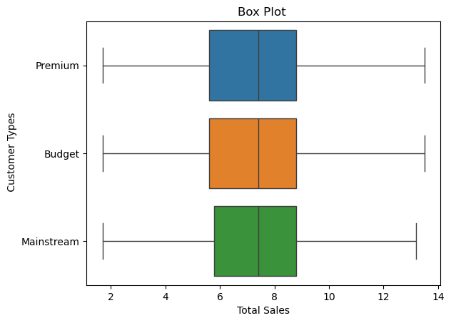

```python
sns.boxplot(y = 'PREMIUM_CUSTOMER', x = 'TOT_SALES' , hue= 'PREMIUM_CUSTOMER', data= chips_df, showfliers = False)
plt.title('Box Plot ')
plt.ylabel(' Customer Types')
plt.xlabel('Total Sales')
plt.show()
```

## Analysis

##### How Many Customer are there?

```python
num_customers = chips_df['LYLTY_CARD_NBR'].nunique()
print(f"Number of Unique Customers: {num_customers}")
```

```
Number of Unique Customers: 70946
```

###### A function to Annotate bars on the given Axes object with their height value.

```python
def annotate_bars(ax, threshold=0.01):
    """
    Annotate bars on the given Axes object with their height value.

    Parameters:
    - ax: The Axes object containing the bar plot.
    - threshold: A value to filter out annotations for very small bars.
    """
    for p in ax.patches:
        height = p.get_height()

        # Only annotate if the height is greater than the threshold
        if height > threshold:
            ax.annotate(f'{height:.2f}',
                        (p.get_x() + p.get_width() / 2., height),
                        ha='center', va='center',
                        fontsize=10, color='black',
                        xytext=(0, 5), textcoords='offset points')
```

##### Which customer segment contributes most to chip sales

```python
# Group by LIFESTAGE and PREMIUM_CUSTOMER, then calculate total sales
total_sales_by_segment = chips_df.groupby(['LIFESTAGE', 'PREMIUM_CUSTOMER'])['TOT_SALES'].sum().reset_index()

total_sales_by_segment.head()
```

|  | LIFESTAGE | PREMIUM_CUSTOMER | TOT_SALES |
| --- | --- | --- | --- |
| 0 | MIDAGE SINGLES/COUPLES | Budget | 32758.80 |
| 1 | MIDAGE SINGLES/COUPLES | Mainstream | 82435.55 |
| 2 | MIDAGE SINGLES/COUPLES | Premium | 53245.75 |
| 3 | NEW FAMILIES | Budget | 20214.95 |
| 4 | NEW FAMILIES | Mainstream | 15605.60 |

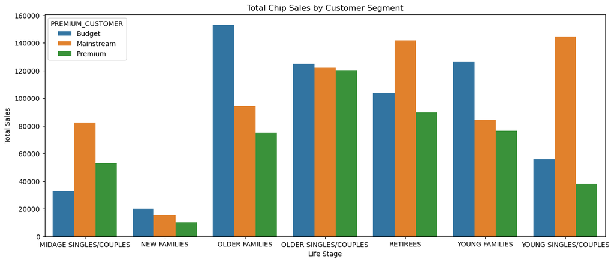

```python
plt.figure(figsize=(15, 6))
ax = sns.barplot(x='LIFESTAGE', y='TOT_SALES', data=total_sales_by_segment, hue='PREMIUM_CUSTOMER')

# Adding title and labels
plt.title('Total Chip Sales by Customer Segment')
plt.xlabel('Life Stage')
plt.ylabel('Total Sales')

# Display the plot
plt.show()
```

The analysis reveals significant variations in total sales across different life stages and premium customer categories. Older families and older singles/couples demonstrate the highest total sales, particularly within the budget and mainstream segments, suggesting that these groups have a strong preference for cost-effective options.

Premium customers generally contribute less across life stages, suggesting that the majority of sales are driven by budget and mainstream segments. This insight can guide targeted marketing strategies, emphasizing mainstream and budget options for older demographics while exploring ways to increase engagement with younger and premium customers.

#### Define Metric: Average Price Per Unit

The aim is to evaluate how different *LIFESTAGE* and *PREMIUM_CUSTOMER* segments influence the selection of chip products

```python
average_price = chips_df.groupby(['LIFESTAGE','PREMIUM_CUSTOMER']).agg(
    Total_Sales=('TOT_SALES', 'sum'),
    Total_Quantity =('PROD_QTY', 'sum')
).reset_index()

average_price['Average_Price_per_Unit'] = average_price['Total_Sales']/average_price['Total_Quantity']

average_price[['LIFESTAGE','PREMIUM_CUSTOMER','Average_Price_per_Unit']].head()
```

|  | LIFESTAGE | PREMIUM_CUSTOMER | Average_Price_per_Unit |
| --- | --- | --- | --- |
| 0 | MIDAGE SINGLES/COUPLES | Budget | 3.743435 |
| 1 | MIDAGE SINGLES/COUPLES | Mainstream | 3.973564 |
| 2 | MIDAGE SINGLES/COUPLES | Premium | 3.762951 |
| 3 | NEW FAMILIES | Budget | 3.929048 |
| 4 | NEW FAMILIES | Mainstream | 3.933854 |

##### Graph

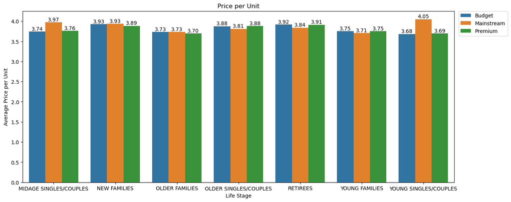

```python
plt.figure(figsize= (15,6))
ax = sns.barplot(x='LIFESTAGE',y='Average_Price_per_Unit',data=average_price, hue = 'PREMIUM_CUSTOMER')

annotate_bars(ax)

plt.title('Price per Unit')
plt.xlabel('Life Stage')
plt.ylabel('Average Price per Unit')
plt.legend(bbox_to_anchor=(1.01, 1), loc='upper left', borderaxespad=0)
plt.show()
```

Retirees exhibit relatively consistent average prices across all segments, indicating steady preferences regardless of premium status. Young singles/couples in the mainstream segment stand out with the highest average price per unit (4.05), suggesting a willingness to pay more for perceived value or premium products.

#### Define Metric: Average Unit per Transaction

The aim is to analyze customer purchasing habits such as whether certain segments buy chips in bulk or prefer single-unit purchases

```python
average_units = chips_df.groupby(['LIFESTAGE', 'PREMIUM_CUSTOMER']).agg(
    Total_Quantity=('PROD_QTY', 'sum'),
    Unique_Customers=('LYLTY_CARD_NBR', 'nunique')
).reset_index()

average_units['Average_Units_per_Transaction'] = average_units['Total_Quantity']/average_units['Unique_Customers']

average_units[['LIFESTAGE','PREMIUM_CUSTOMER','Average_Units_per_Transaction']].head()
```

|  | LIFESTAGE | PREMIUM_CUSTOMER | Average_Units_per_Transaction |
| --- | --- | --- | --- |
| 0 | MIDAGE SINGLES/COUPLES | Budget | 5.969304 |
| 1 | MIDAGE SINGLES/COUPLES | Mainstream | 6.334656 |
| 2 | MIDAGE SINGLES/COUPLES | Premium | 5.972984 |
| 3 | NEW FAMILIES | Budget | 4.763889 |
| 4 | NEW FAMILIES | Mainstream | 4.820170 |

##### Graph

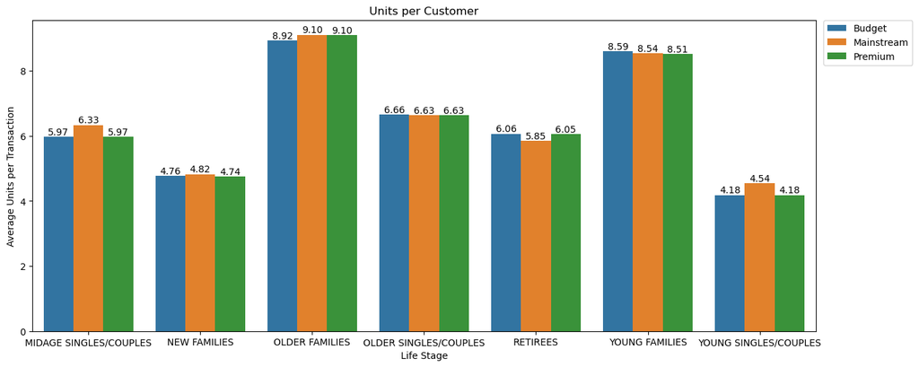

```python
plt.figure(figsize= (15,6))
ax = sns.barplot(x='LIFESTAGE',y='Average_Units_per_Transaction',data=average_units, hue = 'PREMIUM_CUSTOMER')

annotate_bars(ax)

plt.title('Units per Customer')
plt.xlabel('Life Stage')
plt.ylabel('Average Units per Transaction')
plt.legend(bbox_to_anchor=(1.01, 1), loc='upper left', borderaxespad=0)
plt.show()
```

The analysis of average units per transaction offers additional insights into customer behavior and complements previous results on total sales and average price per unit. Older families and young families consistently purchase larger quantities per transaction, with older families leading in all segments (approximately 9 units per transaction), aligning with their dominance in total sales and cost-conscious preferences seen in average price per unit. Similarly, young families show high transaction volumes across all segments, reflecting a bulk-buying tendency, likely driven by household needs.

On the other hand, midage singles/couples and retirees show moderate transaction sizes, with retirees maintaining consistency across all premium levels, reinforcing their steady and balanced purchasing patterns. Young singles/couples exhibit the smallest average units per transaction (approximately 4 units), particularly in budget and premium segments, which correlates with their higher average price per unit in the mainstream category.

These findings highlight the value of tailoring strategies to life stage and segment dynamics: promoting bulk purchase deals to families and offering premium-focused smaller packs to younger singles/couples to enhance sales. The data underscores the potential to drive profitability by aligning product size and pricing strategies with customer transaction behavior.

#### Sales Over Time

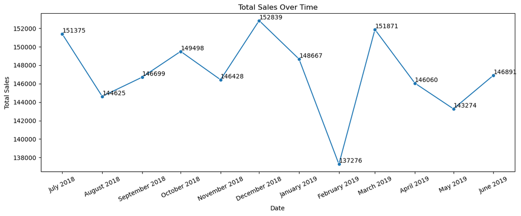

```python
chips_df['YearMonth'] = chips_df['DATE'].dt.to_period('M')
monthly_sales = chips_df.groupby('YearMonth')['TOT_SALES'].sum().reset_index()
monthly_sales['YearMonth'] = monthly_sales['YearMonth'].dt.to_timestamp()
monthly_sales['FormattedDate'] = monthly_sales['YearMonth'].dt.strftime('%B %Y')

plt.figure(figsize=(12, 5))
sns.lineplot(data=monthly_sales, x='YearMonth', y='TOT_SALES', marker='o')

for x, y in zip(monthly_sales['YearMonth'], monthly_sales['TOT_SALES']): plt.text(x, y, f'{y:.0f}', ha='left', va='bottom')

plt.title('Total Sales Over Time')
plt.xlabel('Date')
plt.ylabel('Total Sales')
plt.xticks(monthly_sales['YearMonth'], monthly_sales['FormattedDate'], rotation=25)
plt.tight_layout()
plt.show()
```

The trend analysis over time shows fluctuations in total sales across the 12-month period from July 2018 to June 2019. December 2018 recorded the highest sales at 152,838.90, which may indicate a seasonal spike likely influenced by holiday purchasing behavior. Conversely, February 2019 saw the lowest sales at 137,275.80, suggesting a potential post-holiday slump.

Overall, sales appear relatively stable, with no dramatic upward or downward trends, but noticeable dips in February and May 2019 may warrant further investigation into potential contributing factors, such as seasonality, marketing efforts, or external economic conditions.

When these insights are combined with earlier analyses, the consistently strong performance of certain customer segments (e.g., Older Families and Young Families) aligns with these time-based fluctuations, suggesting these groups may have a significant impact during peak periods.

#### Pack Size Preferences

The goal is to understand how different customer segments (based on LIFESTAGE, PREMIUM_CUSTOMER) prefer certain pack sizes and how these preferences may correlate with their purchasing behavior.

```python
chips_df['Pack_Size'] = chips_df['PROD_NAME'].str.extract(r'(\d+)').astype(int)

# Aggregate total sales and product quantity by pack size
pack_size_summary = chips_df.groupby('Pack_Size').agg({
    'TOT_SALES': 'sum',
    'PROD_QTY': 'sum'
}).reset_index()

# Calculate proportions
pack_size_summary['Sales_Proportion'] = (
    pack_size_summary['TOT_SALES'] / pack_size_summary['TOT_SALES'].sum()
)
pack_size_summary['Quantity_Proportion'] = (
    pack_size_summary['PROD_QTY'] / pack_size_summary['PROD_QTY'].sum()
)
```

##### Graph

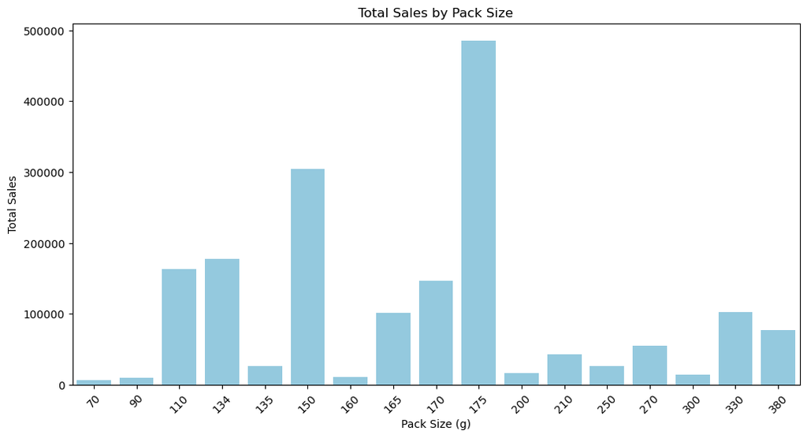

```python
plt.figure(figsize=(12, 6))
sns.barplot(x='Pack_Size', y='TOT_SALES', data=pack_size_summary, color='skyblue')
plt.title('Total Sales by Pack Size')
plt.xlabel('Pack Size (g)')
plt.ylabel('Total Sales')
plt.xticks(rotation=45)
plt.show()
```

#### Compare Pack Sizes Across Segments

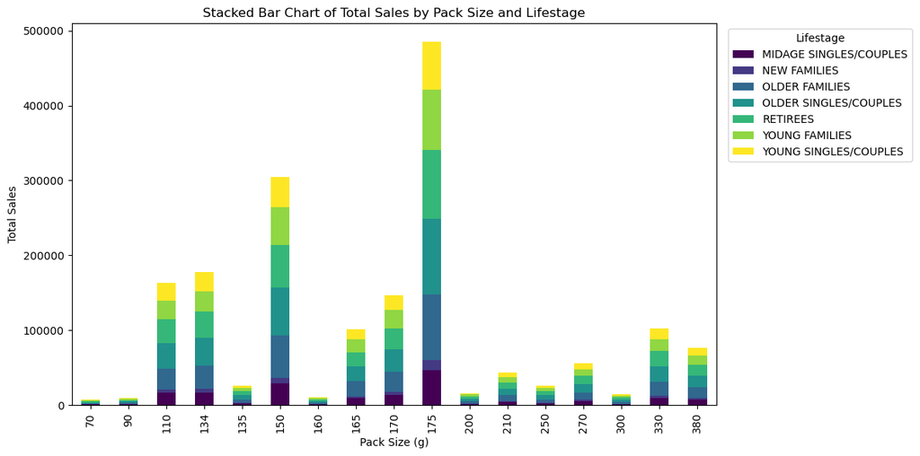

```python
pack_size_segment_summary = chips_df.groupby(['Pack_Size', 'LIFESTAGE', 'PREMIUM_CUSTOMER']).agg({
    'TOT_SALES': 'sum',
    'PROD_QTY': 'sum'
}).reset_index()

# Pivot data for stacked bar chart
sales_pivot = pack_size_segment_summary.pivot_table(
    index='Pack_Size', columns='LIFESTAGE', values='TOT_SALES', aggfunc='sum'
)

# Plot
sales_pivot.plot(kind='bar', stacked=True, figsize=(12, 6), colormap='viridis')
plt.title('Stacked Bar Chart of Total Sales by Pack Size and Lifestage')
plt.xlabel('Pack Size (g)')
plt.ylabel('Total Sales')
plt.legend(title='Lifestage', bbox_to_anchor=(1.01, 1), loc='upper left')
plt.tight_layout()
plt.show()
```

Older Families and Older Singles/Couples exhibit the highest sales contributions across most pack sizes, particularly in the larger pack ranges (150g and 175g), suggesting these groups prioritize value for money or have a higher demand for chips. Retirees also demonstrate significant sales, aligning with their consistent behavior of moderate-to-high engagement in previous analyses.

On the other hand, smaller pack sizes such as 70g and 90g see relatively modest sales, with Young Singles/Couples and Midage Singles/Couples contributing a notable share, possibly reflecting a preference for smaller, more convenient packs. These trends are consistent with earlier observations, reinforcing the influence of life stage and premium category on purchasing patterns, and highlight the importance of targeting promotions and stock strategies around the 150g and 175g pack sizes for maximum impact.

## Summary

### Key Insights Summary:

Average Units Per Transaction: Older families and young families exhibit the highest average units per transaction, indicating bulk buying behavior in these segments. Conversely, segments like Young Singles/Couples and New Families purchase fewer units per transaction, suggesting more occasional or impulse buying.

Trend Analysis Over Time: Total chip sales show seasonal and cyclical trends, with peaks in December, potentially driven by holiday festivities, and lower sales in February. This highlights the importance of aligning marketing campaigns and promotions with seasonal spikes to capitalize on customer demand.

### Overall Insights:

Seasonal trends highlight peaks in sales during December, likely due to holiday festivities, and dips in February. Businesses can leverage this by increasing marketing efforts, running promotions, or offering value packs during peak periods to maximize revenue.

The consistent pricing across customer segments suggests a strategy that works well for mainstream and premium customers. However, there is potential to attract more budget-conscious segments by offering occasional discounts or smaller, affordable packs.

To grow chip sales further, focus should be placed on:

- Targeting Older Customers: Use loyalty programs and promotions on larger pack sizes to retain and grow high-value segments.
- Engaging Younger Demographics: Develop marketing strategies around convenience and affordability, such as smaller pack bundles or student discounts.
- Seasonal Campaigns: Capitalize on seasonal peaks (e.g., December) with festive-themed promotions and offers.
- Product Diversification: Maintain a balanced product mix to appeal to both bulk-buying and occasional-purchase behaviors across different life stages.